# Übung zur Vorlesung ``Text-as-data: Das Beispiel von Ausbildungsordnungen’’

In dieser Übung werden wir die in der Vorlesung behandelte Text-As-Data-Analyse von Ausbildungsordnungen praktisch nachvollziehen. Wir werden folgende Analyseschritte nachvollziehen bzw. selbst durchführen:

1. Ausbildungsordnungen als digitale Forschungsressource kennenlernen,
2. die Extraktion einzelner Kompetenzzeilen aus den Rechtstexten nachvollziehen,
3. Kompetenzen definieren und anhand eines Codebuchs handkodieren
4. die automatisierte Vorkodierung mit einem Sprachmodell nachvollziehen,
5. ein klassisches Textklassifikationsmodell auf diesen Daten trainieren,
6. Sprachmodell, klassisches ML und menschliche Handkodierung anhand unabhängiger Testdaten vergleichen,
7. ausgewählte Kompetenzzeilen selbst mit frei zugänglichen Chatmodellen klassifizieren und
8. Stärken, Grenzen und Validierungsanforderungen der Verfahren diskutieren.

Planen Sie ungefähr **60 bis 75 Minuten** ein. Die fertige Übung kann ohne Installation im Browser gelesen werden.

**Hinweis**

**Optional: R-Code selbst ausführen**

Wenn Sie den R-Code selbst ausführen möchten:

1. Installieren Sie [R über CRAN](https://cran.r-project.org/).
2. Installieren Sie [RStudio Desktop](https://posit.co/download/rstudio-desktop/). Quarto ist in aktuellen RStudio-Versionen enthalten; andernfalls hilft die [Quarto-Installationsanleitung](https://quarto.org/docs/get-started/).
3. Laden Sie das [GitHub-Repository](https://github.com/ingoisphording/digital_skills_vet) über **Code → Download ZIP** herunter und entpacken Sie es.
4. Öffnen Sie `source/digital_skills_vet.Rproj` und führen Sie `source/setup.R` einmal vollständig aus.
5. Öffnen Sie anschließend `source/digital_skills_vet.qmd`. Sie können einzelne Codeblöcke ausführen oder mit **Render** die gesamte Seite neu erzeugen.

## 1. Ausbildungsordnungen als Ressource

Wir verwenden die jeweils aktuelle digitale Fassung von fünf Ausbildungsordnungen:

Amtliche Anlagen der Ausbildungsordnungen

| Ausbildungsberuf | Fassung | Amtliche Fassung |
| --- | --- | --- |
| Kaufmann/Kauffrau für Büromanagement | 2025 | [Anlage öffnen](https://www.gesetze-im-internet.de/b_romkfausbv_2025/anlage.html) |
| Fachinformatiker/Fachinformatikerin | 2020 | [Anlage öffnen](https://www.gesetze-im-internet.de/fiausbv/anlage.html) |
| Friseur/Friseurin | 2008 | [Anlage öffnen](https://www.gesetze-im-internet.de/friseurausbv_2008/anlage.html) |
| Elektroniker/Elektronikerin | 2021 | [Anlage öffnen](https://www.gesetze-im-internet.de/elekausbv_2021/anlage.html) |
| Mechatroniker/Mechatronikerin | 2011 | [Anlage öffnen](https://www.gesetze-im-internet.de/mechatronikerausbv/anlage_1.html) |

Die Kompetenzbeschreibungen stehen in den Anlagen der Ausbildungsordnungen, die im Rechtstext teilweise „Ausbildungsrahmenplan“ heißen. Der Begriff kann deshalb in einzelnen Abschnittsnamen des Datensatzes auftauchen. Untersucht werden dennoch die Ausbildungsordnungen, nicht eine zusätzliche Datenquelle.

## 2. Extraktion von Kompetenzen

Im ersten Schritt extrahieren wir die Kompetenzzeilen aus den digital vorliegenden Ausbildungsordnungen. Dazu dienen das kommentierte R-Skript zum Herunterladen der HTML-Seiten und das R-Skript zur Extraktion der Kompetenzzeilen.

Die Skripte

- speichern einen datierten Snapshot jeder amtlichen HTML-Anlage,
- erkennen Berufsbildpositionen und ihre buchstabierten Unterpunkte,
- verbinden gegebenenfalls einen gemeinsamen Einleitungssatz mit dem jeweiligen Unterpunkt und
- speichern jede Kompetenzzeile mit Beruf, Abschnitt, Berufsbildposition, Fachrichtung beziehungsweise Wahlqualifikation und Quellenlink.

Der resultierende Datensatz enthält insgesamt 895 Kompetenzzeilen. Je nach Beruf sind es zwischen 140 und 239:

Extrahierte Kompetenzzeilen nach Ausbildungsberuf

| Ausbildungsberuf | Anzahl |
| --- | --- |
| Elektroniker/Elektronikerin | 207 |
| Fachinformatiker/Fachinformatikerin | 144 |
| Friseur/Friseurin | 140 |
| Kaufmann/Kauffrau für Büromanagement | 239 |
| Mechatroniker/Mechatronikerin | 165 |

Einige Ordnungen enthalten neben gemeinsamen Inhalten zusätzliche Zeilen für bestimmte Fachrichtungen oder Wahlqualifikationen. Eine einzelne Person absolviert nicht alle diese Alternativen. Die Variablen `track_type` und `track_name` halten deshalb fest, für wen eine Zeile gilt.

Fünf Beispielzeilen, die später erneut verwendet werden:

Beispiele aus dem extrahierten Datensatz

| Fall | Beruf | Berufsbildposition | Kompetenzzeile |
| --- | --- | --- | --- |
| 1 | Kaufmann/Kauffrau für Büromanagement | digitalisierte Arbeitswelt (§ 4 Absatz 4 Nummer 4) | Aufgaben zusammen mit Beteiligten, einschließlich der Beteiligten anderer Arbeits- und Geschäftsbereiche, auch unter Nutzung digitaler Medien, planen, bearbeiten und gestalten |
| 2 | Elektroniker/Elektronikerin | Durchführen von Wiederholungsprüfungen entsprechend geltender Normen und Instandhalten von gebäudetechnischen Systemen (§ 4 Absatz 3 Nummer 6) | Wartungsarbeiten durchführen |
| 3 | Fachinformatiker/Fachinformatikerin | Betreiben von IT-Systemen (§ 4 Absatz 2 Nummer 8) | Störungsmeldungen aufnehmen und analysieren sowie Maßnahmen zur Störungsbeseitigung ergreifen |
| 4 | Friseur/Friseurin | Digitalisierte Arbeitswelt (§ 4 Absatz 2 Abschnitt C Nummer 4) | Risiken bei der Nutzung von digitalen Medien und informationstechnischen Systemen einschätzen und bei deren Nutzung betriebliche Regelungen einhalten |
| 5 | Mechatroniker/Mechatronikerin | Zusammenbauen von Baugruppen und Komponenten zu Maschinen und Systemen (§ 3 Absatz 2 Nummer 17) | Sensoren einbauen, einstellen und verbinden |

## 3. Fragestellung und Konzeptualisierung

Die Forschungsfrage, die wir beantworten wollen, lautet:

> Wie hoch ist der Anteil digitaler Kompetenzen, die eine Ausbildungsordnung definiert?

Wir fragen also, wie sehr sich definierte Berufe in ihren Kompetenzprofilen unterscheiden. Da wir jeweils die aktuell gültige Fassung der Ausbildungsordnungen betrachten, betrachten wir keine Entwicklung über die Zeit. Unsere Arbeitsdefinition für eine digitale Kompetenz lautet:

> Eine Kompetenzzeile ist digital, wenn ihre Erfüllung ausdrücklich die Nutzung, Konfiguration, Entwicklung, Steuerung oder Analyse digitaler Systeme, Software, Daten oder automatisierter digitaler Prozesse erfordert.

Jede Kompetenzzeile erhält `1` für digital oder `0` für nicht digital. Der digitale Anteil eines Berufs ist die Zahl digital kodierter Zeilen geteilt durch die Zahl aller einbezogenen Zeilen.

Zwei einfache Ankerbeispiele:

- „Teilaufgaben von IT-Systemen automatisieren“ → digital
- „Bedarfe von Kunden und Kundinnen feststellen“ → nicht digital

Für Grenzfälle verwenden wir ein dokumentiertes Codebuch, nicht nur unser Bauchgefühl.

## 4. Übung: Handkodierung

Wir beginnen zunächst damit, zehn Übungsfälle selbst per Hand zu kodieren. Die kleine Auswahl dient dazu, das Codebuch anzuwenden und unterschiedliche Entscheidungen nachvollziehbar zu machen. Die eigentliche Modellevaluation in Schritt 5 verwendet eine davon getrennte, größere Testmenge.

Zehn Testfälle für die Handkodierung

| ID | Beruf | Berufsbildposition | Kompetenzzeile |
| --- | --- | --- | --- |
| elektroniker_a_11_b | Elektroniker/Elektronikerin | Montieren und Installieren von Netzwerken (§ 4 Absatz 2 Nummer 11) | Standardsoftware und Anwendungssoftware nach Einsatzbereichen auswählen, konfigurieren und anpassen sowie Kompatibilität zu Hardware- und Systemvoraussetzungen beurteilen und installieren |
| elektroniker_d_2_f | Elektroniker/Elektronikerin | Sicherheit und Gesundheit bei der Arbeit (§ 4 Absatz 5 Nummer 2) | Verhaltensweisen bei Unfällen beschreiben und erste Maßnahmen bei Unfällen einleiten |
| fachinformatiker_e_1_c | Fachinformatiker/Fachinformatikerin | Analysieren und Planen von Systemen zur Vernetzung von Prozessen und Produkten (§ 4 Absatz 6 Nummer 1) | bei der Planung Aspekte der IT-Sicherheit und technische Rahmenbedingungen, insbesondere Netzwerkanforderungen, berücksichtigen |
| fachinformatiker_f_2_a | Fachinformatiker/Fachinformatikerin | Aufbau und Organisation des Ausbildungsbetriebes (§ 4 Absatz 7 Nummer 2) | die Rechtsform und den organisatorischen Aufbau des Ausbildungsbetriebes mit seinen Aufgaben und Zuständigkeiten sowie die Zusammenhänge zwischen den Geschäftsprozessen erläutern |
| friseur_a_2_4_b | Friseur/Friseurin | Dauerhaft Umformen (§ 4 Abs. 2 Abschnitt A Nr. 2.4) | Präparate auswählen und einsetzen |
| friseur_c_4_b | Friseur/Friseurin | Digitalisierte Arbeitswelt (§ 4 Absatz 2 Abschnitt C Nummer 4) | Risiken bei der Nutzung von digitalen Medien und informationstechnischen Systemen einschätzen und bei deren Nutzung betriebliche Regelungen einhalten |
| bueromanagement_b_7_d | Kaufmann/Kauffrau für Büromanagement | Assistenzaufgaben übernehmen (§ 4 Absatz 3 Nummer 7) | Kommunikationsstörungen vermeiden |
| bueromanagement_c_4_g | Kaufmann/Kauffrau für Büromanagement | digitalisierte Arbeitswelt (§ 4 Absatz 4 Nummer 4) | Aufgaben zusammen mit Beteiligten, einschließlich der Beteiligten anderer Arbeits- und Geschäftsbereiche, auch unter Nutzung digitaler Medien, planen, bearbeiten und gestalten |
| mechatroniker_main_15_g | Mechatroniker/Mechatronikerin | Aufbauen und Prüfen von Steuerungen (§ 3 Absatz 2 Nummer 15) | Sensoren, Aktoren und Wandler installieren |
| mechatroniker_main_4_d | Mechatroniker/Mechatronikerin | Umweltschutz (§ 3 Absatz 2 Nummer 4) | Zur Vermeidung betriebsbedingter Umweltbelastungen im beruflichen Einwirkungsbereich beitragen, insbesondere Abfälle vermeiden, Stoffe und Materialien einer umweltschonenden Entsorgung zuführen |

1. Laden Sie die Kodiermaske herunter.
2. Vergeben Sie für jede Zeile `1` oder `0`.
3. Ergänzen Sie eine Konfidenz von `0.25`, `0.50`, `0.75` oder `1.00` sowie eine kurze Begründung.
4. Verwenden Sie Lernziel, Berufsbildposition und Beruf als Kontext, aber unterstellen Sie keine nicht genannten Tätigkeiten.

**Tipp**

**Erst nach eigener Kodierung vergleichen!**

Dozierendenreferenz für die zehn Testfälle

| ID | Kompetenzzeile | Referenz | Begründung |
| --- | --- | --- | --- |
| elektroniker_a_11_b | Standardsoftware und Anwendungssoftware nach Einsatzbereichen auswählen, konfigurieren und anpassen sowie Kompatibilität zu Hardware- und Systemvoraussetzungen beurteilen und installieren | 1 | Auswahl, Konfiguration, Anpassung und Installation von Standard- und Anwendungssoftware sind ausdrücklich digitale Handlungen an Software. |
| elektroniker_d_2_f | Verhaltensweisen bei Unfällen beschreiben und erste Maßnahmen bei Unfällen einleiten | 0 | Unfallverhalten und erste Maßnahmen bei Unfällen enthalten keine ausdrücklich digitale Teilkompetenz. |
| fachinformatiker_e_1_c | bei der Planung Aspekte der IT-Sicherheit und technische Rahmenbedingungen, insbesondere Netzwerkanforderungen, berücksichtigen | 1 | IT-Sicherheit und Netzwerkanforderungen werden ausdrücklich als technische Planungsbedingungen genannt. |
| fachinformatiker_f_2_a | die Rechtsform und den organisatorischen Aufbau des Ausbildungsbetriebes mit seinen Aufgaben und Zuständigkeiten sowie die Zusammenhänge zwischen den Geschäftsprozessen erläutern | 0 | Rechtsform, Aufbau, Zuständigkeiten und Geschäftsprozesse beschreiben betriebliche Organisation ohne ausdrücklichen digitalen Bezug. |
| friseur_a_2_4_b | Präparate auswählen und einsetzen | 0 | Auswahl und Einsatz von Präparaten ist eine stoffbezogene Fachkompetenz ohne digitalen Bezug. |
| friseur_c_4_b | Risiken bei der Nutzung von digitalen Medien und informationstechnischen Systemen einschätzen und bei deren Nutzung betriebliche Regelungen einhalten | 1 | Digitale Medien und informationstechnische Systeme werden ausdrücklich genannt und ihre regelgerechte Nutzung verlangt. |
| bueromanagement_b_7_d | Kommunikationsstörungen vermeiden | 0 | Kommunikationsstörungen können auch in nichtdigitaler Kommunikation auftreten; ein digitales System wird nicht genannt. |
| bueromanagement_c_4_g | Aufgaben zusammen mit Beteiligten, einschließlich der Beteiligten anderer Arbeits- und Geschäftsbereiche, auch unter Nutzung digitaler Medien, planen, bearbeiten und gestalten | 1 | Die Nutzung digitaler Medien wird ausdrücklich als Mittel zur gemeinsamen Planung, Bearbeitung und Gestaltung von Aufgaben genannt. |
| mechatroniker_main_15_g | Sensoren, Aktoren und Wandler installieren | 1 | Die Berufsbildposition „Aufbauen und Prüfen von Steuerungen“ ordnet Sensoren, Aktoren und Wandler einem mechatronischen Steuerungssystem zu; ihre Installation ist Teil der digitalen Steuerungskompeten… |
| mechatroniker_main_4_d | Zur Vermeidung betriebsbedingter Umweltbelastungen im beruflichen Einwirkungsbereich beitragen, insbesondere Abfälle vermeiden, Stoffe und Materialien einer umweltschonenden Entsorgung zuführen | 0 | Abfallvermeidung und umweltschonende Entsorgung sind Umweltkompetenzen ohne digitale Handlung. |

## 5. LLM-Vorkodierung und klassisches ML

Für die Umsetzung eines supervised ML-Verfahrens benötigen wir eine umfassende Vorkodierung. Im Idealfall würden hier unabhängige Votings menschlicher Experten herangezogen werden. Für diese Übung haben wir stattdessen alle 895 Kompetenzzeilen zunächst mit `gpt-5.4-nano-2026-03-17` auf Basis des Codebuchs vorkodiert (dieser Schritt ist bereits ausgeführt – Sie benötigen keine OpenAI-API). Diese LLM-Labels sind **Silver Labels**: Sie ermöglichen ein großes Trainingsset, sind aber nicht der angestrebte Goldstandard.

**HinweisBegriffserklärung: Supervised ML**

Ein supervised-ML-Verfahren lernt aus Beispielen, bei denen das richtige Label bereits bekannt ist. Hier sieht das Modell Kompetenzzeilen mit der Zuordnung `digital` oder `nicht digital` und lernt daraus, neue Zeilen zu klassifizieren.

**HinweisBegriffserklärung: API**

Eine API ist eine Programmierschnittstelle. Über sie kann ein Skript ein Modell wie OpenAI Nano automatisch ansprechen. In dieser Übung ist dieser Schritt bereits dozierendenseitig ausgeführt; Studierende benötigen keinen API-Schlüssel.

1. 805 Kompetenzzeilen bilden das Trainingsset mit LLM-Silver-Labels.
2. 90 zurückgehaltene Zeilen sind zudem dozierendenseitig blind und ohne Kenntnis der LLM-Antworten kodiert worden. Diese Labels bilden einen menschlichen Experten-Goldstandard.
3. Sowohl das LLM als auch eine regularisierte logistische Regression mit TF-IDF-Wortmerkmalen werden gegen dieselben 90 Goldlabels geprüft.

**HinweisBegriffserklärung: TF-IDF-Wortmerkmale**

TF-IDF steht für **Term Frequency – Inverse Document Frequency**. Das Verfahren beschreibt Texte über die Wörter, die in ihnen vorkommen, gewichtet diese Wörter aber unterschiedlich. Ein Wort erhält ein höheres Gewicht, wenn es in einer bestimmten Kompetenzzeile häufig oder besonders charakteristisch vorkommt (*term frequency*), aber im gesamten Datensatz nicht überall auftaucht (*inverse document frequency*).

Die Logik dahinter: Wörter wie „durchführen“, „beachten“ oder „anwenden“ kommen in vielen Ausbildungsordnungen vor und helfen daher wenig, digitale von nicht-digitalen Kompetenzen zu unterscheiden. Wörter wie „Software“, „IT-Systeme“, „Daten“ oder „automatisieren“ sind seltener und für unsere Fragestellung informativer. TF-IDF sorgt dafür, dass solche unterscheidenden Wörter im Modell stärker zählen als sehr häufige Allgemeinwörter.

Evaluation auf 90 blind handkodierten Kompetenzzeilen

| Verfahren | Fälle | Accuracy | Precision | Recall | F1 | False Positives | False Negatives |
| --- | --- | --- | --- | --- | --- | --- | --- |
| OpenAI Nano | 90 | 0.92 | 0.61 | 1.00 | 0.76 | 7 | 0 |
| Klassisches ML | 90 | 0.93 | 0.73 | 0.73 | 0.73 | 3 | 3 |

**HinweisBegriffserklärung: Accuracy, Precision und Recall**

Accuracy, Precision und Recall sind Metriken, um die Vorhersagegüte eines Modells zu beschreiben. **Accuracy** misst den Anteil aller korrekt klassifizierten Fälle. Wenn 84 von 90 Fällen richtig sind, beträgt die Accuracy 84/90 = 0,93. Bei unausgewogenen Daten kann Accuracy aber täuschen, weil ein Modell viele Fälle richtig klassifizieren kann, indem es fast immer die häufige Kategorie vorhersagt.

**Precision** fragt: Von allen Fällen, die das Modell als digital klassifiziert, wie viele sind laut Goldstandard tatsächlich digital? Hohe Precision bedeutet wenige Fehlalarme. Ein solcher Fehlalarm heißt **False Positive**: Das Modell sagt `digital`, der Goldstandard sagt aber `nicht digital`.

**Recall** fragt umgekehrt: Von allen tatsächlich digitalen Fällen, wie viele findet das Modell? Hoher Recall bedeutet, dass wenige digitale Fälle übersehen werden. Ein übersehener digitaler Fall heißt **False Negative**: Das Modell sagt `nicht digital`, der Goldstandard sagt aber `digital`.

**F1** fasst Precision und Recall in einer Kennzahl zusammen. Der Wert ist besonders nützlich, wenn beide Fehlerarten relevant sind: digitale Fälle nicht übersehen, aber auch nicht zu viele nicht-digitale Fälle fälschlich als digital markieren.

Die Stichprobe der handkodierten Fälle ist sehr ungleich verteilt. Nur 11 der 90 handkodierten Testfälle sind digitale Kompetenzen. Deshalb ist Accuracy allein wenig aussagekräftig: Ein Modell kann viele Fälle richtig klassifizieren, indem es fast immer „nicht digital“ vorhersagt. Nano erkennt zwar alle 11 digitalen Fälle, stuft aber zusätzlich 7 nicht-digitale Fälle fälschlich als digital ein. Das klassische ML ist konservativer: Es erzeugt 3 solche Fehlalarme, übersieht dafür aber 3 tatsächlich digitale Fälle.

Erst nach dieser Evaluation wird das klassische Modell mit allen verfügbaren Silver- und Goldlabels neu geschätzt und auf den Gesamtkorpus angewandt:

ML-Klassifikation aller Kompetenzzeilen

| Ausbildungsberuf | Kompetenzzeilen | davon digital | digitaler Anteil |
| --- | --- | --- | --- |
| Elektroniker/Elektronikerin | 207 | 20 | 0.10 |
| Fachinformatiker/Fachinformatikerin | 144 | 92 | 0.64 |
| Friseur/Friseurin | 140 | 6 | 0.04 |
| Kaufmann/Kauffrau für Büromanagement | 239 | 4 | 0.02 |
| Mechatroniker/Mechatronikerin | 165 | 19 | 0.12 |

Die folgende Abbildung zeigt, wie sensibel der berechnete digitale Anteil auf das verwendete Klassifikationsverfahren reagiert. Verglichen werden hier zwei Verfahren, die für alle 895 Kompetenzzeilen vorliegen: die LLM-Vorkodierung und das abschließende klassische ML-Modell.

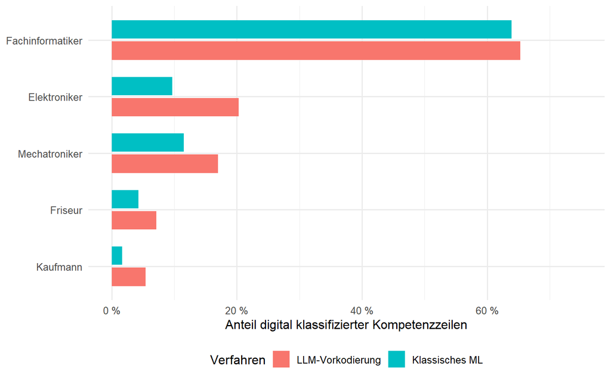

Abbildung 1: Digitaler Kompetenzanteil nach Ausbildungsberuf und Klassifikationsverfahren

Die Unterschiede sind kein technisches Detail, sondern inhaltlich relevant: Das LLM stuft insgesamt mehr Zeilen als digital ein. Das klassische ML-Modell ist nach der Prüfung gegen die 90 handkodierten Goldlabels konservativer, insbesondere bei den Elektronikerinnen und Elektronikern.

Auf Berufsebene beträgt die Korrelation zwischen den LLM- und ML-Anteilen 0.99. Die Rangfolge der Berufe ist also ähnlich, die absolute Höhe der Anteile unterscheidet sich aber.

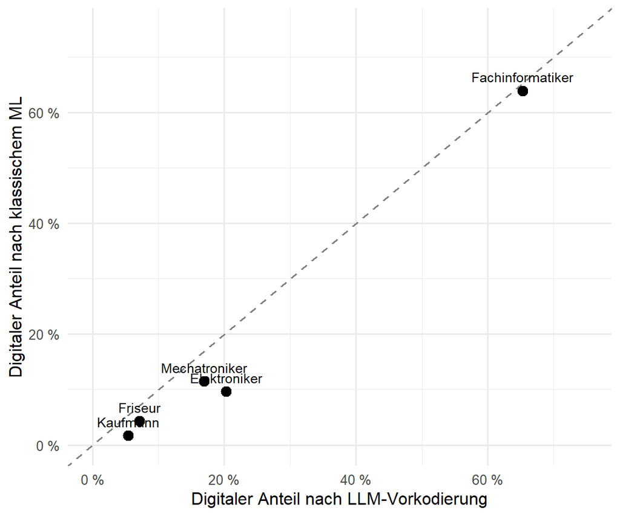

Abbildung 2: Zusammenhang zwischen LLM- und ML-Anteilen auf Berufsebene

Die Werte bleiben ein Demonstrationsergebnis und sind keine belastbare Rangliste der Berufe. Insbesondere sind fachrichtungs- und wahlqualifikationsspezifische Zeilen nicht für jede ausgebildete Person gemeinsames Curriculum.

## 6. Vergleich: ML und eigene Handkodierung

Vergleichen Sie nun Ihre zehn Labels mit der Dozierendenreferenz und den Anwendungsprognosen des abschließenden klassischen Modells. Diese Einzelfallprognosen illustrieren die Modellanwendung; die unabhängige Güteprüfung ist die 90-Fälle-Evaluation aus Schritt 5.

Referenz, LLM und ML auf den zehn Testfällen

| Kompetenzzeile | Referenz | LLM-Label | LLM-Konfidenz | ML-Wahrscheinlichkeit | ML-Label | Ergebnis |
| --- | --- | --- | --- | --- | --- | --- |
| Standardsoftware und Anwendungssoftware nach Einsatzbereichen auswählen, konfigurieren und anpassen sowie Kompatibilität zu Hardware- und Systemvoraussetzungen beurteilen und installieren | 1 | 1 | 1 | 0.66 | 1 | True Positive |
| Verhaltensweisen bei Unfällen beschreiben und erste Maßnahmen bei Unfällen einleiten | 0 | 0 | 1 | 0.07 | 0 | True Negative |
| bei der Planung Aspekte der IT-Sicherheit und technische Rahmenbedingungen, insbesondere Netzwerkanforderungen, berücksichtigen | 1 | 1 | 1 | 0.59 | 1 | True Positive |
| die Rechtsform und den organisatorischen Aufbau des Ausbildungsbetriebes mit seinen Aufgaben und Zuständigkeiten sowie die Zusammenhänge zwischen den Geschäftsprozessen erläutern | 0 | 0 | 1 | 0.11 | 0 | True Negative |
| Präparate auswählen und einsetzen | 0 | 0 | 1 | 0.06 | 0 | True Negative |
| Risiken bei der Nutzung von digitalen Medien und informationstechnischen Systemen einschätzen und bei deren Nutzung betriebliche Regelungen einhalten | 1 | 1 | 1 | 0.64 | 1 | True Positive |
| Kommunikationsstörungen vermeiden | 0 | 0 | 1 | 0.03 | 0 | True Negative |
| Aufgaben zusammen mit Beteiligten, einschließlich der Beteiligten anderer Arbeits- und Geschäftsbereiche, auch unter Nutzung digitaler Medien, planen, bearbeiten und gestalten | 1 | 1 | 1 | 0.40 | 0 | False Negative |
| Sensoren, Aktoren und Wandler installieren | 1 | 0 | 1 | 0.12 | 0 | False Negative |
| Zur Vermeidung betriebsbedingter Umweltbelastungen im beruflichen Einwirkungsbereich beitragen, insbesondere Abfälle vermeiden, Stoffe und Materialien einer umweltschonenden Entsorgung zuführen | 0 | 0 | 1 | 0.05 | 0 | True Negative |

Beantworten Sie kurz:

1. Bei welchen Fällen weicht Ihre Kodierung von der Referenz ab?
2. Welche False Positives und False Negatives erzeugt das ML-Modell?
3. Liegt die Abweichung eher an einzelnen Wörtern, am beruflichen Kontext oder an der Arbeitsdefinition?

## 7. Sensibilität der LLM-Klassifikation

LLM-Klassifikationen sind nicht vollständig deterministisch und hängen stark von der konkreten Anwendungssituation ab. Kleine Änderungen am Prompt können zu anderen Labels oder Begründungen führen. Selbst bei identischem Prompt können verschiedene Modelle unterschiedliche Entscheidungen treffen, weil sie anders trainiert, anders abgestimmt oder anders in das jeweilige Chatprodukt eingebettet sind.

In diesem Schritt testen Sie diese Sensibilität händisch. Zwei frei zugängliche Chatmodelle klassifizieren dieselben fünf Fälle, die in Schritt 2 als Beispiele angezeigt wurden. Eine API oder lokale LLM-Installation ist dafür nicht erforderlich.

1. Wählen Sie zwei Chatmodelle, beispielsweise ChatGPT und Gemini.
2. Beginnen Sie bei jedem Modell einen neuen Chat.
3. Übergeben Sie beiden Modellen den identischen vorbereiteten Prompt.
4. Verwenden Sie jeweils nur die erste Antwort und verändern Sie den Prompt nicht nachträglich.
5. Übertragen Sie Label, Konfidenz und Begründung in je eine Kopie der Ergebnisvorlage.
6. Dokumentieren Sie Dienst, angezeigten Modellnamen und Datum. Geben Sie keine personenbezogenen Daten in den Chat ein.

**Tipp**

**Vergleichswerte erst nach beiden Modellantworten öffnen**

Referenz und klassisches ML für die fünf LLM-Fälle

| Fall | Kompetenzzeile | Referenz | ML-Wahrscheinlichkeit | ML-Label |
| --- | --- | --- | --- | --- |
| 1 | Aufgaben zusammen mit Beteiligten, einschließlich der Beteiligten anderer Arbeits- und Geschäftsbereiche, auch unter Nutzung digitaler Medien, planen, bearbeiten und gestalten | 1 | 0.40 | 0 |
| 2 | Wartungsarbeiten durchführen | 0 | 0.13 | 0 |
| 3 | Störungsmeldungen aufnehmen und analysieren sowie Maßnahmen zur Störungsbeseitigung ergreifen | 1 | 0.49 | 0 |
| 4 | Risiken bei der Nutzung von digitalen Medien und informationstechnischen Systemen einschätzen und bei deren Nutzung betriebliche Regelungen einhalten | 1 | 0.64 | 1 |
| 5 | Sensoren einbauen, einstellen und verbinden | 0 | 0.05 | 0 |

Vergleichen Sie anschließend:

1. Bei welchen Fällen stimmen Handkodierung, ML und beide Chatmodelle überein?
2. Welches Verfahren berücksichtigt den beruflichen Kontext am besten?
3. Ist eine plausible Begründung automatisch ein Hinweis auf ein korrektes Label?

Fünf Fälle reichen nicht für eine Rangliste von Modellen. Ein einzelner zusätzlicher Treffer verändert die Accuracy bereits um 0,20.

## 8. Abschließende Diskussion

| Verfahren | Stärke | Zentrale Grenze |
| --- | --- | --- |
| Handkodierung | transparente inhaltliche Entscheidung | zeitaufwendig und schwer skalierbar |
| Klassisches ML | auf große Korpora anwendbar | benötigt gelabelte Trainingsdaten und generalisiert möglicherweise schlecht |
| Chatmodell | ohne eigene Modellschätzung leicht zugänglich | Modellversion und Laufbedingungen sind nur begrenzt kontrollierbar |

Diskutieren Sie abschließend:

1. Welche Entscheidungen wurden bereits vor der eigentlichen Klassifikation getroffen?
2. Welches Verfahren würden Sie für einen großen historischen Korpus wählen?
3. Welche zusätzliche Referenzstichprobe wäre für eine belastbare Evaluation notwendig?
4. Was misst der berechnete digitale Anteil – und was misst er ausdrücklich nicht?

Die zentrale Botschaft lautet: Der Weg vom Rechtstext zur quantitativen Variable ist selbst ein Forschungsbeitrag. Kein Klassifikationsverfahren ersetzt eine klare Definition, nachvollziehbare Datenaufbereitung und unabhängige Validierung.